# R package

Nathan Preuss

2020-10-18

# Introduction

Congratulations for getting this far. To complete the evidence that you have made a working R package please answer the following by using the supplied rmd and upload the knitted html to CANVAS.

I will assume your package is called **MATH4753PREU0001** and you have packaged and documented functions `chebyshev`, `nathancltp`, `bindif` and `fitCompare`.

Your actual package name and functions will obviously be called something else.

# First function

Please place your first function in the r chunk in the following way:

Once you are ready please remove the option `eval = FALSE`

```r
MATH4753PREU0001::chebyshev(2, c(1,2,3,4,5,6,7,8,9,11,13,16,18,21))
```

```
## [1] 1
```

```r
MATH4753PREU0001::chebyshev(1, c(1,2,3,11,13,16,18,21,34,41,56))
```

```
## [1] 0.6363636
```

# Second function

Please place your second function in the r chunk in the following way:

Once you are ready please remove the option `eval = FALSE`

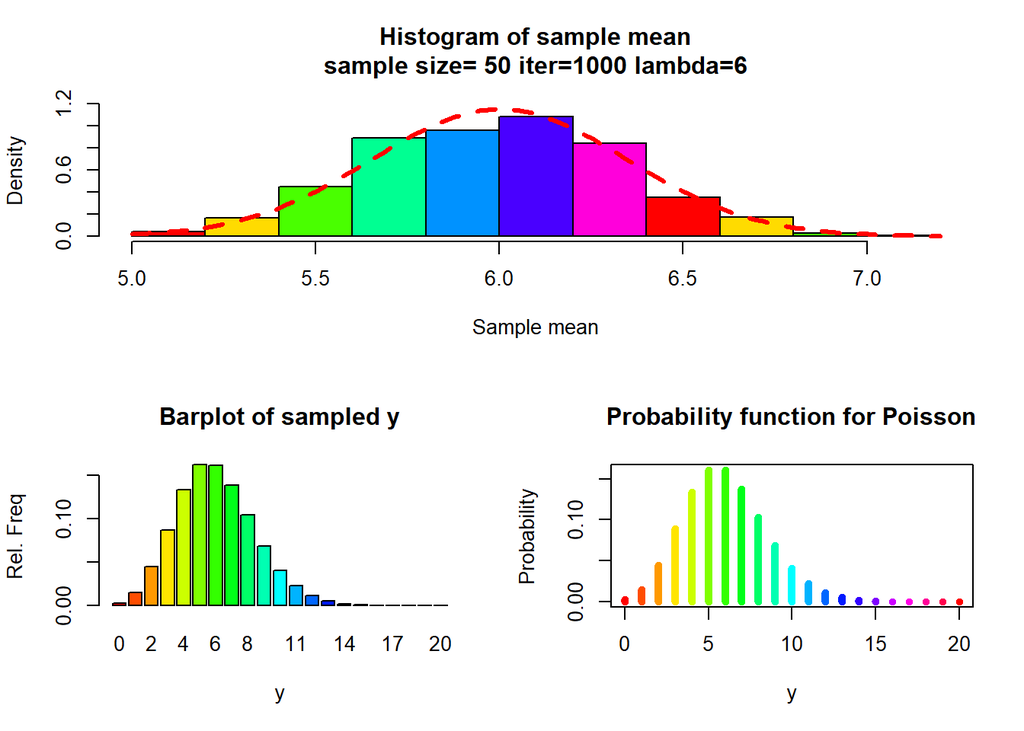

```r
MATH4753PREU0001::nathancltp(50, 1000, 6)
```

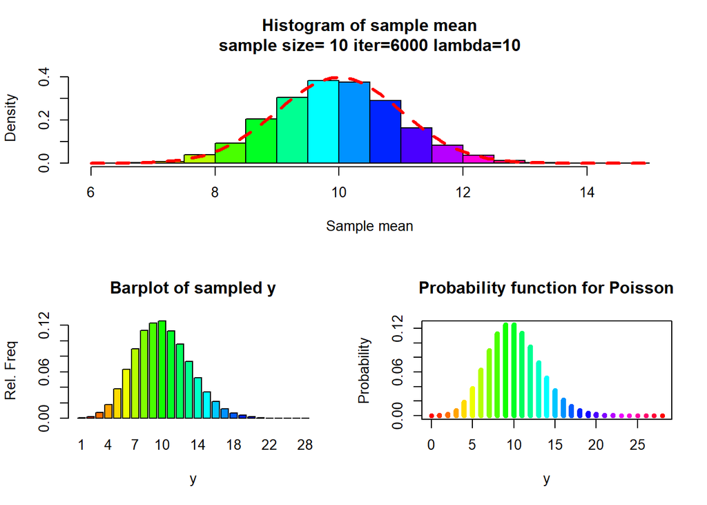

```r
MATH4753PREU0001::nathancltp(10, 6000)
```

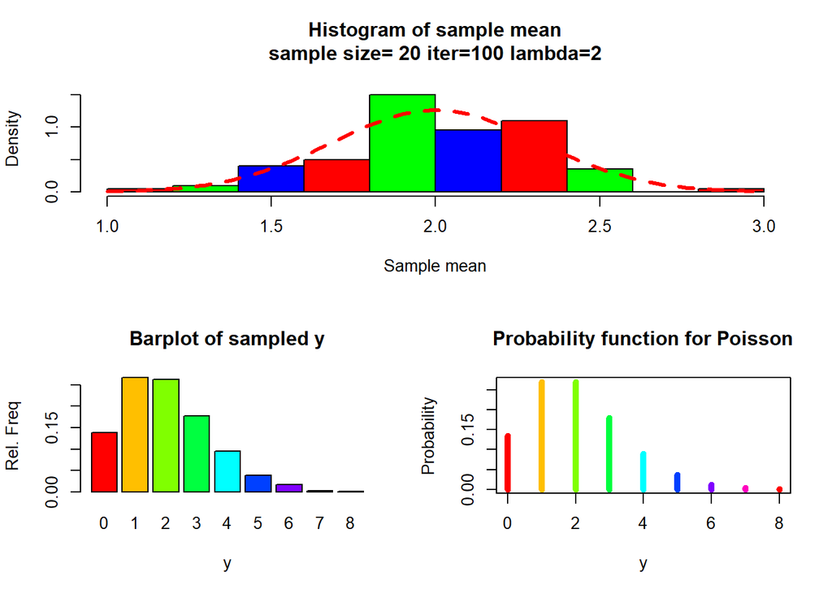

```r
MATH4753PREU0001::nathancltp(20, 100, 2)
```

# Third function

Please place your third function in the r chunk in the following way:

Once you are ready please remove the option `eval = FALSE`

```r
MATH4753PREU0001::bindif()
```

```
##         name     X0       X1      X2     X3      X4       X5       X6      X7
## 1     sample  0e+00  0.00010 0.00220 0.0094 0.03790  0.09710  0.19300 0.27070
## 2     dbinom  1e-05  0.00014 0.00145 0.0090 0.03676  0.10292  0.20012 0.26683
## 3 difference -1e-05 -0.00004 0.00075 0.0004 0.00114 -0.00582 -0.00712 0.00387
##        X8      X9      X10
## 1 0.23770 0.12380  0.02810
## 2 0.23347 0.12106  0.02825
## 3 0.00423 0.00274 -0.00015
```

```r
MATH4753PREU0001::bindif(iter=10000, n=8, p=0.2)
```

```
##         name       X0      X1      X2     X3       X4       X5      X6      X7
## 1     sample  0.16550 0.33910  0.2912 0.1537  0.04010  0.00900 0.00120 0.00020
## 2     dbinom  0.16777 0.33554  0.2936 0.1468  0.04588  0.00918 0.00115 0.00008
## 3 difference -0.00227 0.00356 -0.0024 0.0069 -0.00578 -0.00018 0.00005 0.00012
##   X8
## 1  0
## 2  0
## 3  0
```

```r
MATH4753PREU0001::bindif(iter = 500)
```

```
##         name     X0       X1      X2    X3       X4       X5       X6       X7
## 1     sample  0e+00  0.00000 0.00400 0.018  0.02800  0.08400  0.18800  0.25600
## 2     dbinom  1e-05  0.00014 0.00145 0.009  0.03676  0.10292  0.20012  0.26683
## 3 difference -1e-05 -0.00014 0.00255 0.009 -0.00876 -0.01892 -0.01212 -0.01083
##        X8      X9     X10
## 1 0.25600 0.13000 0.03600
## 2 0.23347 0.12106 0.02825
## 3 0.02253 0.00894 0.00775
```

```r
MATH4753PREU0001::bindif(n=7)
```

```
##         name       X0       X1      X2      X3      X4       X5       X6
## 1     sample  0.00000  0.00310  0.0248 0.09850 0.23150  0.31640  0.24680
## 2     dbinom  0.00022  0.00357  0.0250 0.09724 0.22689  0.31765  0.24706
## 3 difference -0.00022 -0.00047 -0.0002 0.00126 0.00461 -0.00125 -0.00026
##         X7
## 1  0.07890
## 2  0.08235
## 3 -0.00345
```

```r
MATH4753PREU0001::bindif(p=0.5)
```

```
##         name      X0       X1      X2       X3      X4      X5       X6
## 1     sample 0.00100  0.00960 0.04600  0.11600 0.20580 0.25120  0.20000
## 2     dbinom 0.00098  0.00977 0.04395  0.11719 0.20508 0.24609  0.20508
## 3 difference 0.00002 -0.00017 0.00205 -0.00119 0.00072 0.00511 -0.00508
##         X7      X8       X9      X10
## 1  0.11530 0.04560  0.00870  0.00080
## 2  0.11719 0.04395  0.00977  0.00098
## 3 -0.00189 0.00165 -0.00107 -0.00018
```

```r
MATH4753PREU0001::bindif(n=8, p=0.2)
```

```
##         name       X0       X1      X2     X3      X4      X5       X6    X7 X8
## 1     sample  0.16360  0.33290  0.2912 0.1540 0.04770 0.00960  0.00090 1e-04  0
## 2     dbinom  0.16777  0.33554  0.2936 0.1468 0.04588 0.00918  0.00115 8e-05  0
## 3 difference -0.00417 -0.00264 -0.0024 0.0072 0.00182 0.00042 -0.00025 2e-05  0
```

# Forth function

Please place your forth function in the r chunk in the following way:

Once you are ready please remove the option `eval = FALSE`

```r
x <- c(1:20)
y <- c(2:21)
z <- c(1,4,6,8,1,2,6,4,1,2,3,4,6,2,3,8,6,4,3,2)
MATH4753PREU0001::fitCompare(stats::lm(y~x),stats::lm(z~x))
```

```
## Warning in summary.lm(m1): essentially perfect fit: summary may be unreliable
```

```
## [[1]]
## [1] "model 1"
```

```r
MATH4753PREU0001::fitCompare(stats::lm(z~x),stats::lm(z~y))
```

```
## [[1]]
## [1] "same"
```

Yes, there is a warning, but that’s just because I gave it a model with perfect fit on purpose.